# Tutorial 4 at NTU: Bayes Classifier

```python
from importlib import reload
import numpy as np
import pandas as pd
import matplotlib.pyplot as plt

from sklearn.model_selection import train_test_split, cross_val_score
from sklearn.metrics import precision_recall_fscore_support
from sklearn.naive_bayes import CategoricalNB, GaussianNB
from CIBer import CIBer
from scikitplot.metrics import plot_cumulative_gain, plot_lift_curve, plot_roc
```

```python
def confusion_matrix_metrics(y_test, y_pred):
    y_test = pd.Series(np.array(y_test), name='truth')
    y_pred = pd.Series(np.array(y_pred), name='pred')

    all_classes = np.sort(pd.concat([y_test, y_pred]).unique())

    conf_mat = y_pred.groupby([y_pred, y_test]).count().unstack()
    conf_mat = conf_mat.reindex(all_classes).reindex(all_classes, axis=1).fillna(0).astype(int)

    test_stat = precision_recall_fscore_support(y_test, y_pred, labels=all_classes, zero_division=np.nan)
    test_stat = pd.DataFrame({stat: score for stat, score in
                              zip(['precision', 'recall', 'fscore', 'support'], test_stat)},
                              index=all_classes)
    return conf_mat, test_stat
```

## 1. Naive Bayes Classifier

Suppose that we are given a training set with $n$ samples \begin{equation*} \mathcal{D} = \{(\mathbf x^1, c(\mathbf x^1)), (\mathbf x^2, c(\mathbf x^2)), \dots, (\mathbf x^n, c(\mathbf x^n)) \} \, , \end{equation*} where each object is represented by its binary (dummy) feature vector $\mathbf x^i = (x_1^i,\dots,x^i_d) \in \{0, 1\}^d$ and $c(\mathbf x^i)$ is the corresponding classification.

Let $\mathcal{C} = \{c_1,\dots, c_\ell\}$ be the set of all possible classification labels that $c(\mathbf x)$ may take values in. The empirical probability is then: \begin{equation} \mathbb{P}({\rm c}(\mathbf x^*) = c_j | {\bf x}=\mathbf x^*) = \frac{\mathbb{P}({\bf x}=\mathbf x^* | {\rm c}(\mathbf x^*) = c_j) \mathbb{P}({\rm c}(\mathbf x^*) = c_j)}{\mathbb{P}({\bf x}=\mathbf x^*)} \, , \end{equation} where the law of total probabilities tells us that: \begin{equation*} \mathbb{P}({\bf x}=\mathbf x^*) = \sum_{j=1}^\ell \mathbb{P}({\bf x}=\mathbf x^* | {\rm c}(\mathbf x^*) = c_j) \mathbb{P}({\rm c}(\mathbf x^*) = c_j) \, . \end{equation*} We can easily compute the empirical probability of the label as: \begin{equation*} \hat{\mathbb{P}} ({\rm c}(\mathbf x)=c_j) = \frac{|i: c(\mathbf x^i) = c_j|}{|\mathcal{D}|} \, . \end{equation*}

However, these empirical probabilities would be accurate estimates for the true conditional probabilities,

only when the sample size is large enough that can cover most of the combinations of $\mathbf x$ and $c(\mathbf x)$ in $\mathcal{X}$ and $\mathcal{C}$ respectively.

We therefore consider a naive model, that is, we assume all the $p$ features are conditionally independent.

### 1.1 Conditional Independence

Then, the conditional probability becomes \begin{equation} \begin{aligned} \mathbb{P}({\rm c}(\mathbf x^*) = c_j | {\bf x}=\mathbf x^*) &= \frac{\prod\limits_{k=1}^d \mathbb{P}({\rm x}_k=x_k^*|{\rm c}(\mathbf x^*)=c_j) \mathbb{P}({\rm c}(\mathbf x^*)=c_j)}{\mathbb{P}({\bf x}=\mathbf x^*)} \\ &\propto \prod_{k=1}^d \mathbb{P}({\rm x}_k=x_k^*|{\rm c}(\mathbf x^*)=c_j) \mathbb{P}({\rm c}(\mathbf x^*)=c_j) \, . \end{aligned} \end{equation}

Hence, with a constant number of possible values for each feature, less training samples are required.

Note: if each combination has one observation, there are $2 \times d \times |\mathcal{C}|$ entries.

Under this naive assumption, the empirical probabilities can be estimated by \begin{equation} p_{kj} := \hat{\mathbb{P}}_{\rm Dummy} ({\rm x}_k=x_k|{\rm c}(\mathbf x)=c_j) = \frac{|i: x_k^i=x_k, c(\mathbf x^i)=c_j|}{|i: c(\mathbf x^i) = c_j|} \, , \qquad x_k \in \{0, 1\} \, , \end{equation}

### 1.2 Categorical Naive Bayes

Dummy Naive Bayes classifier only deals with binary feature matrix, while its categorical version can deal with any possible integers

(If each combination has one observation, there are $|\mathcal{X}_1| \times |\mathcal{X}_2| \times \cdots \times |\mathcal{X}_p| \times |\mathcal{C}|$ entries).

The settings in Categorical Naive Bayes classifier and in Dummy Na"ive Bayes classifier are the same:

\begin{equation} q_{kj} := \hat{\mathbb{P}}_{\mathbf Cate} ({\mathbf x}_k=x_k|{\mathbf c}(\mathbf x)=c_j) = \frac{|i: x_k^i=x_k, c(\mathbf x^i)=c_j|}{|i: c(\mathbf x^i) = c_j|} \, , \qquad x_k \in \mathcal{X}_k \, , \end{equation}

## 2. Distributional Naive Bayes Classifier

We can impose different distribution assumptions to the feature matrix such that we have:

1. Bernoulli Naive Bayes Classifier
2. Multinomial Naive Bayes Classifier
3. Gaussian Naive Bayes Classifier

### 2.1 Bernoulli Naive Bayes Classifier

If each feature variable are binary, we can assume that each conditional feature variables follow a Bernoulli distribution.

Using the definition as in $\hat{\mathbb{P}}_{\rm Dummy}$, we have \begin{equation*} \hat{\mathbb{P}}_{\rm Bern} ({\mathbf x}_k=x_k|{\rm c}(\mathbf x)=c_j) = p_{kj}^{x_k} (1 - p_{kj})^{1 - x_k} \, , \qquad x_k \in \{0, 1\} \, . \end{equation*}

### 2.2 Multinomial Naive Bayes Classifier

In the circumstance of multinomial event model, the feature vector $x$ of length $d$ denotes the frequencies of $m$ random variables,

where the events have been generated by a multinomial distribution $(p_1, \cdots ,p_d)$.

With the defintion as in $\hat{\mathbb{P}}_{\mathbf Cate}$, the **likelihood** of an observation $\mathbf x$ given a certain class $c_{j}$ is defined as: \begin{equation*} \hat{\mathbb{P}}_{\rm Multi} ({\bf x}=\mathbf x | {\rm c}(\mathbf x) = c_j) = \frac{(\sum_{k=1}^d x_k)!}{\prod_{k=1}^d x_k!} \cdot \prod_{k=1}^d q_{kj}^{x_k} \, , \qquad x_k \in \mathcal{X}_k \, . \end{equation*}

### 2.3 Gaussian Naive Bayes Classifier

In the previous two event models, the variables follow discrete distributions.

However, if the variables are real-valued, a Gaussian distribution can be assumed for each conditional variable.

Suppose that $x_k$ is a real-valued feature, we first partition the data by the class,

and then compute its sample mean $\mu_{kj}$ and sample standard deviation $\sigma_{kj}$ within each class $c_{j}$.

The empirical conditional density of $x_k$ given $c_j$ is estimated by: \begin{equation} \hat{\mathbb{P}}_{\rm Gauss} ({\rm x}_k=x_k|{\rm c}(\mathbf x)=c_j) = \frac{1}{\sqrt{2\pi \sigma^{2}_{kj}}} \exp\left(-\frac{(x_k-\mu_{kj})^{2}}{2\sigma^{2}_{kj}}\right) \, , \qquad -\infty < x_k < \infty \, . \end{equation}

Of course, we can apply discretization technique to the continuous feature variables,

such that the Categorical Naive Bayes classifier can be adopted to the resulting dataset instead.

Nonetheless, there must be information loss.

### 2.4 Composite Naive Bayes Classifier

In general, the dataset contains different types of feature variables, including continuous, categorical, and discrete.

Since we naively assumed the conditional independence, we can combine several distributional Naive Bayes model as a composite model.

For example, if feature variables ${\rm x}_1$ and ${\rm x}_2$ are categorical,

${\rm x}_3, {\rm x}_4, {\rm x}_5, {\rm x}_6$ follow a multinomial distribution,

and ${\rm x}_7, {\rm x}_8$ are real-valued such that we assume they follow Gaussian distribution,

the empirical likelihood of $\mathbf x = (x_1, \cdots, x_8)$ given class $c_j$ becomes:

\begin{align*} \hat{\mathbb{P}}_{comp}({\bf x}=\mathbf x | {\rm c}(\mathbf x) = c_j) &= \hat{\mathbb{P}}_{\rm Cate} ({\rm x}_1=x_1|{\rm c}(\mathbf x)=c_j) \cdot \hat{\mathbb{P}}_{\rm Cate} ({\rm x}_2=x_2|{\rm c}(\mathbf x)=c_j) \\ &\quad \times \hat{\mathbb{P}}_{\rm Multi} (({\rm x}_3, {\rm x}_4, {\rm x}_5, {\rm x}_6)=(x_3, x_4, x_5, x_6) | {\rm c}(\mathbf x) = c_j) \\ &\quad \times \hat{\mathbb{P}}_{\rm Gauss} ({\rm x}_7=x_7|{\rm c}(\mathbf x)=c_j) \cdot \hat{\mathbb{P}}_{\rm Gauss} ({\rm x}_8=x_8|{\rm c}(\mathbf x)=c_j) \, . \end{align*}

Practical Computation

If we have predicted probabilities from $m$ naive bayes classifiers, then we can combine them by:

### 3. Demo on Bank Churners Dataset

Given a dataset of consumer credit card information, we want to predict customers who are likely to drop off (customer attrition).

Source: `https://www.kaggle.com/code/thomaskonstantin/bank-churn-data-exploration-and-churn-prediction/data`

```python
df = pd.read_csv('BankChurners.csv', index_col=0)
df_descr = pd.concat({'dtype': df.dtypes, 'n_uniq': df.nunique()}, axis=1)
display(df_descr.sort_values(['n_uniq', 'dtype']))
```

|  | dtype | n_uniq |
| --- | --- | --- |
| Attrition_Flag | object | 2 |
| Gender | object | 2 |
| Marital_Status | object | 4 |
| Card_Category | object | 4 |
| Dependent_count | int64 | 6 |
| Total_Relationship_Count | int64 | 6 |
| Income_Category | object | 6 |
| Months_Inactive_12_mon | int64 | 7 |
| Contacts_Count_12_mon | int64 | 7 |
| Education_Level | object | 7 |
| Months_on_book | int64 | 44 |
| Customer_Age | int64 | 45 |
| Total_Trans_Ct | int64 | 126 |
| Total_Ct_Chng_Q4_Q1 | float64 | 830 |
| Avg_Utilization_Ratio | float64 | 964 |
| Total_Amt_Chng_Q4_Q1 | float64 | 1158 |
| Total_Revolving_Bal | int64 | 1974 |
| Total_Trans_Amt | int64 | 5033 |
| Credit_Limit | float64 | 6205 |
| Avg_Open_To_Buy | float64 | 6813 |

```python
# Encode categorical features
cate_cols = ['Attrition_Flag', 'Gender', 'Education_Level', 'Marital_Status', 'Income_Category', 'Card_Category']
cat_mapping = {}
for cat in cate_cols:
    cat_encoding = pd.factorize(df[cat])
    df[cat] = cat_encoding[0]
    cat_mapping[cat] = cat_encoding[1]
```

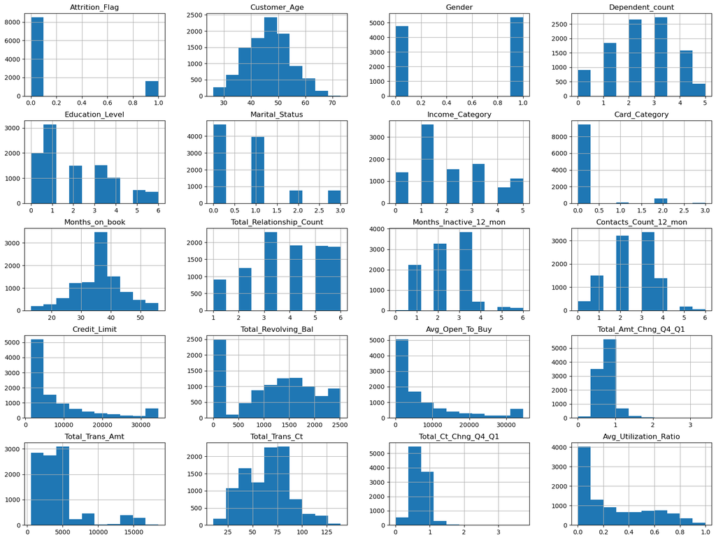

```python
df.hist(figsize=(20, 15));
```

```python
target = 'Attrition_Flag'

X = df.drop(columns=target)
y = df[target]

cont_col_names = list(set(X.columns) - set(cate_cols))
col_name_map = {col: i for i, col in enumerate(X.columns)}
cont_cols = [col_name_map[col] for col in cont_col_names]

X_train, X_test, y_train, y_test = train_test_split(X.values, y.values, test_size=0.2, random_state=12345)
```

### 3.1 Naive Bayes Classifier

```python
def split_cate_cont(X, cont_cols):
    X_cate = np.delete(X, cont_cols, axis=1)
    X_cont = X[:, cont_cols]
    return X_cate, X_cont

X_train_cate, X_train_cont = split_cate_cont(X_train, cont_cols)
X_test_cate, X_test_cont = split_cate_cont(X_test, cont_cols)
```

#### 3.1.1 Categorical

```python
clf_cate = CategoricalNB()
clf_cate.fit(X_train_cate, y_train)
y_pred_prob_cate = clf_cate.predict_proba(X_test_cate)
y_pred_cate = np.argmax(y_pred_prob_cate, axis=1)

conf_mat_cate, test_stat_cate = confusion_matrix_metrics(y_test, y_pred_cate)
display(conf_mat_cate, test_stat_cate)
```

| truth pred | 0 | 1 |
| --- | --- | --- |
| 0 | 1701 | 325 |
| 1 | 0 | 0 |

|  | precision | recall | fscore | support |
| --- | --- | --- | --- | --- |
| 0 | 0.839585 | 1.0 | 0.912798 | 1701 |
| 1 | NaN | 0.0 | 0.000000 | 325 |

#### 3.1.2 Gaussian

```python
clf_nb = GaussianNB()
clf_nb.fit(X_train_cont, y_train)
y_pred_prob_cont = clf_nb.predict_proba(X_test_cont)
y_pred_cont = np.argmax(y_pred_prob_cont, axis=1)

conf_mat_cont, test_stat_cont = confusion_matrix_metrics(y_test, y_pred_cont)
display(conf_mat_cont, test_stat_cont)
```

| truth pred | 0 | 1 |
| --- | --- | --- |
| 0 | 1613 | 117 |
| 1 | 88 | 208 |

|  | precision | recall | fscore | support |
| --- | --- | --- | --- | --- |
| 0 | 0.932370 | 0.948266 | 0.940251 | 1701 |
| 1 | 0.702703 | 0.640000 | 0.669887 | 325 |

#### 3.1.3 Composite

```python
y_pred_prob_comp = (y_pred_prob_cate * y_pred_prob_cont)
y_pred_prob_comp = y_pred_prob_comp / clf_nb.class_prior_
y_pred_prob_comp = y_pred_prob_comp / y_pred_prob_comp.sum(axis=1)[:, None]

y_pred_comp = np.argmax(y_pred_prob_comp, axis=1)
conf_mat_comp, test_stat_comp = confusion_matrix_metrics(y_test, y_pred_comp)
display(conf_mat_comp, test_stat_comp)
```

| truth pred | 0 | 1 |
| --- | --- | --- |
| 0 | 1613 | 118 |
| 1 | 88 | 207 |

|  | precision | recall | fscore | support |
| --- | --- | --- | --- | --- |
| 0 | 0.931831 | 0.948266 | 0.939977 | 1701 |
| 1 | 0.701695 | 0.636923 | 0.667742 | 325 |

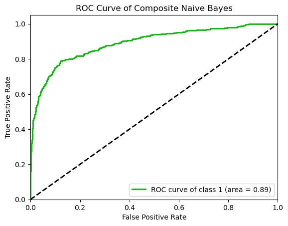

```python
plot_roc(y_test, y_pred_prob_comp, title='ROC Curve of Composite Naive Bayes',
         classes_to_plot=[1], plot_macro=False, plot_micro=False);
```

### 3.2 CIBer

CIBer provided both organized treatments on all categorical, continuous and discrete feature variables

and efficient modelling of the **dependence structure** among them.

#### 3.2.1 Motivation

**treat the features within groups as comonotonic** while the totality of features in a group is independent of those in another group.

#### 3.2.2 Comonotonicity

It describes a special dependence among several random variables in that whenever the realization of one variable changes,

the realizations of all other variables would change in the same direction.

This synchronized movement manifests the extremal positive dependence,

which often corresponds to the extremal behaviour of a stochastic system involving variables with fixed marginal distributions but in face of unknown dependence.

Definition

A set $S\subset\mathbb{R}^d$ is comonotonic if:

\begin{equation*} \text{For any } \mathbf{x}, \mathbf{y} \in S, \text{ either } \mathbf{x} \geq \mathbf{y} \text{ or } \mathbf{x} \leq \mathbf{y}. \end{equation*}

A random vector $\mathbf{X}$ in $\mathbb{R}^d$ is comonotonic if $\mathbb{P}(\mathbf{X}\in S)=1$ for some comonotonic set $S\subset\mathbb{R}^d$.

Proposition

Suppose that $\mathbf{X} = (X_1,\dots,X_d)$ is a random vector whose marginal cumulative distribution functions are $F_{X_1},\dots,F_{X_d}$, respectively.

Then:

\begin{equation*} F_{\mathbf{X}}(\mathbf{x})=\min_i F_{X_i}(x_i) \text{ for all } \mathbf{x}=(x_1,\dots,x_d) \end{equation*}

#### 3.2.3 Parameters of CIBer

`cont_col` is a list of indices for the continuous feature variables.

`asso_method` specifies our correlation measures.

`disc_method` specifies our discretization strategy for `cont_col`.

`min_asso` is the minimum threshold adopted in when we want to cluster features with their pairwise association.

```python
CIBer_kwargs = {'cont_col': cont_cols,
                'asso_method': 'modified',
                'min_asso': 0.95,
                'disc_method': 'wpkid',
                'alpha': 1,
                'jointEncode': True,
}

mod = CIBer(**CIBer_kwargs)
mod.fit(X_train, y_train)
```

```python
col_name_map_rev = {v: k for k, v in col_name_map.items()}
cluster_book = pd.DataFrame(mod.cluster_book).map(lambda s: [col_name_map_rev[c] for c in s])
cluster_book = cluster_book.map(lambda s: s[0] if len(s) == 1 else s)
cluster_book
```

|  | 0 | 1 |
| --- | --- | --- |
| 0 | Customer_Age | Customer_Age |
| 1 | Gender | Gender |
| 2 | Dependent_count | Dependent_count |
| 3 | Education_Level | Education_Level |
| 4 | Marital_Status | Marital_Status |
| 5 | Income_Category | Income_Category |
| 6 | [Card_Category, Credit_Limit] | [Card_Category, Credit_Limit] |
| 7 | Months_on_book | Months_on_book |
| 8 | Total_Relationship_Count | Total_Relationship_Count |
| 9 | Months_Inactive_12_mon | Months_Inactive_12_mon |
| 10 | Contacts_Count_12_mon | Contacts_Count_12_mon |
| 11 | Total_Revolving_Bal | Total_Revolving_Bal |
| 12 | Avg_Open_To_Buy | Avg_Open_To_Buy |
| 13 | Total_Amt_Chng_Q4_Q1 | Total_Amt_Chng_Q4_Q1 |
| 14 | Total_Trans_Amt | Total_Trans_Amt |
| 15 | Total_Trans_Ct | Total_Trans_Ct |
| 16 | Total_Ct_Chng_Q4_Q1 | Total_Ct_Chng_Q4_Q1 |
| 17 | Avg_Utilization_Ratio | Avg_Utilization_Ratio |

From CIBer, a comonotonic structure between `Card_Category` and `Credit_Limit` is discovered.

In particular, `Card_Category` is a categorical feature variable representing the level of the credit card.

It is then obvious that a premium card level would yield a greater amount in `Credit_Limit`.

```python
y_pred = mod.predict(X_test)
conf_mat, test_stat = confusion_matrix_metrics(y_test, y_pred)
display(conf_mat, test_stat)
```

| truth pred | 0 | 1 |
| --- | --- | --- |
| 0 | 1618 | 53 |
| 1 | 83 | 272 |

|  | precision | recall | fscore | support |
| --- | --- | --- | --- | --- |
| 0 | 0.968282 | 0.951205 | 0.959668 | 1701 |
| 1 | 0.766197 | 0.836923 | 0.800000 | 325 |

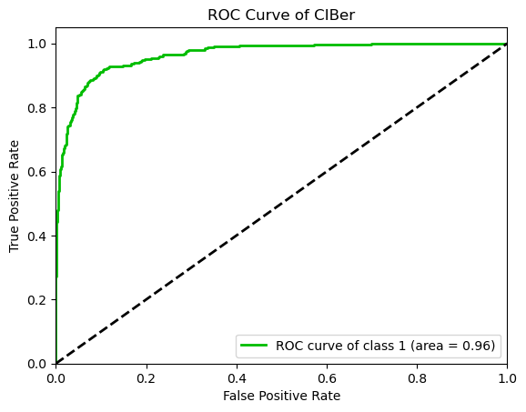

```python
y_pred_prob = mod.predict_proba(X_test)
plot_roc(y_test, y_pred_prob, title='ROC Curve of CIBer',
         classes_to_plot=[1], plot_macro=False, plot_micro=False);
```

With CIBer, we achieve a much better result compared with Naive Bayes Model.

In conclusion, these additional structures in CIBer help improve predictive performance:

1. Joint Encoding of Categorical Features
2. Clustering of Dependent Features
3. Modelling of Comonontonic Features